# Machine Learning Engineer Nanodegree

#### Target: Loan Status

It is time to take a closer look at the feature that we care the most about, which is, the **target** feature which we hope to predict accurately. In our data, it is denoted by the field name **loan_status**.

We will first review the distribution of the field and then assess if we need to handle it in any mannner. We shall be converting it to a binary feature with possible values of 0 to denote that someone **Paid_in_Full** and 1 to denote **Default**.

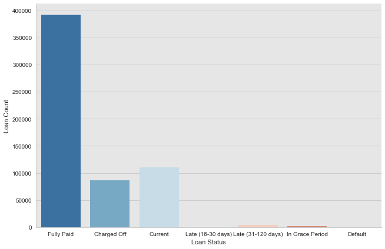

```python
sns.set_style("whitegrid", {"axes.facecolor": ".9"})

# Draw a count plot to show the number of events of each type
g = sns.factorplot(x='loan_status', data=all_loans_data, kind="count",
                   palette="RdBu_r", size=6, aspect=1.5)
g.ax.set(xlabel='Loan Status', ylabel='Loan Count')
plt.show()
```

```python
LoanStatusDescription = [
    "Loan has been fully paid off.",
    "Loan is up to date on current payments.",
    "Loan has been charged-off.",
    "Loan hasn't been paid in 31 to 120 days ",
    "The loan is in the grace period of 15 days past due.",
    "Loan hasn't been paid in 16 to 30 days",
    "Loan is defaulted on and no payment has been made for more than 121 days."]

#loanStatus, StatusCount = all_loans_data["loan_status"].value_counts().index, all_loans_data["loan_status"].value_counts().values
StatusCount=all_loans_data['loan_status'].value_counts()/ all_loans_data.shape[0]*100.0
LoanStatusCount = pd.DataFrame({'Proportion': StatusCount,'Description': LoanStatusDescription})[['Proportion','Description']]
LoanStatusCount
```

|  | Proportion | Description |
| --- | --- | --- |
| Fully Paid | 65.729895 | Loan has been fully paid off. |
| Current | 18.530167 | Loan is up to date on current payments. |
| Charged Off | 14.555890 | Loan has been charged-off. |
| Late (31-120 days) | 0.727100 | Loan hasn't been paid in 31 to 120 days |
| In Grace Period | 0.298774 | The loan is in the grace period of 15 days pas... |
| Late (16-30 days) | 0.155162 | Loan hasn't been paid in 16 to 30 days |
| Default | 0.003013 | Loan is defaulted on and no payment has been m... |

Upon a closer look it appears that it consist of values which are other than *Fully Paid* and *Charged Off (Default)*. For our purposes, we need to be sure of an account's terminal status, hence it is advisable for us to only consider those loans which have either fully paid or have charged-off. I have written a small function in the *utilities.py* script which will filter the dataframe and convert the data type for the column.

```python
#cleaning "loan_status"

LoanData = ut.fix_loan_status(all_loans_data)
```

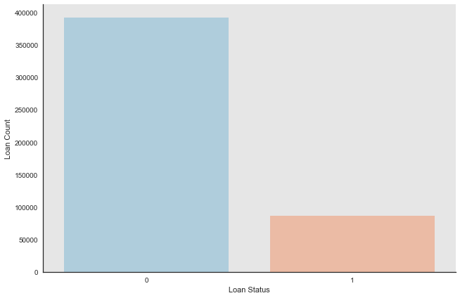

```python
sns.set_style("white", {"axes.facecolor": ".9"})

# Draw a count plot to show the number of events of each type
g = sns.factorplot(x='loan_status', data=LoanData, kind="count",
                   palette="RdBu_r", size=6, aspect=1.5)
g.ax.set(xlabel='Loan Status', ylabel='Loan Count')
plt.show()
```

```python
# Removing % sign from the interest rate and changing the datatype

LoanData['int_rate'] = LoanData['int_rate'].apply(ut.fix_int_rate)
```

```python
#cleaning "zip" and removing trailing xxx

display(LoanData.zip_code.value_counts(dropna=False).sort_index().head())
LoanData['zip_code'] = LoanData['zip_code'].apply(ut.fix_zip_code)
display(LoanData.zip_code.value_counts(dropna=False).sort_index().head())
```

```
007xx      4
008xx      1
010xx    792
011xx    220
012xx    179
Name: zip_code, dtype: int64
```

```
007      4
008      1
010    792
011    220
012    179
Name: zip_code, dtype: int64
```

```python
# Removing months from term
display(LoanData.term.value_counts(dropna=False).sort_index())
LoanData['term'] = LoanData['term'].apply(ut.fix_term)
display(LoanData.term.value_counts(dropna=False).sort_index())
```

```
 36 months    373076
 60 months    106585
Name: term, dtype: int64
```

```
36    373076
60    106585
Name: term, dtype: int64
```

To clean up the employment length, we will remove the text and convert <1 year to 0.

```python
#Convert n/a to 0 and <1 to 0
display(LoanData.emp_length.value_counts(dropna=False).sort_index())
# Removing year(s) from term
LoanData = ut.fix_emp_length(LoanData)
display(LoanData.emp_length.value_counts(dropna=False).sort_index())
```

```
0             23026
1 year        30871
10+ years    152745
2 years       42855
3 years       38176
4 years       28954
5 years       31708
6 years       26324
7 years       25878
8 years       23020
9 years       18477
< 1 year      37627
Name: emp_length, dtype: int64
```

```
0      60653
1      30871
2      42855
3      38176
4      28954
5      31708
6      26324
7      25878
8      23020
9      18477
10    152745
Name: emp_length, dtype: int64
```

Next we will clean all the columns with date type of data by converting them to pandas datetime. This will make it easier for us to analyze the data by dates.

```python
#Fix Dates
dt_cols = [col for col in LoanData.columns if '_d' in col]
dt_cols.append("earliest_cr_line")
display(LoanData[dt_cols].tail(2).T)
#LoanData["issue_month"], LoanData["issue_year"] = zip(*LoanData.issue_d.str.split('-'))
LoanData['last_credit_pull_dt']=pd.to_datetime(LoanData.last_credit_pull_d, format='%b-%Y')
LoanData['issue_dt']=pd.to_datetime(LoanData.issue_d, format='%b-%Y')
LoanData['earliest_cr_line_dt']=pd.to_datetime(LoanData.earliest_cr_line, format='%b-%Y')
#dt_cols.append("issue_year")
#dt_cols.append("issue_month")
display(LoanData[['last_credit_pull_dt','issue_dt','earliest_cr_line_dt']].tail(2).T)
display(LoanData.issue_dt.dt.year.value_counts(dropna=False).sort_values(na_position='first',ascending=False).head(20))
```

|  | 597475 | 597476 |
| --- | --- | --- |
| issue_d | Jan-2016 | Jan-2016 |
| last_credit_pull_d | Dec-2017 | Oct-2017 |
| earliest_cr_line | Sep-1999 | Jul-2002 |

|  | 597475 | 597476 |
| --- | --- | --- |
| last_credit_pull_dt | 2017-12-01 | 2017-10-01 |
| issue_dt | 2016-01-01 | 2016-01-01 |
| earliest_cr_line_dt | 1999-09-01 | 2002-07-01 |

```
2014    208119
2013    126872
2012     53287
2016     51599
2011     21721
2010     11535
2009      4716
2008      1562
2007       250
Name: issue_dt, dtype: int64
```

At the same time, we will drop any columns which are of no longer any use to us.

```python
# Drop unncessary columns
LoanData.drop(['verification_status','zip_code','last_credit_pull_d','earliest_cr_line','issue_d','emp_title'],
              axis = 1, inplace = True)
```

Let's review our data types after data cleaning to ensure that they are of appropriate data types.

```python
with pd.option_context('display.max_rows', 150, 'display.max_columns', 3):
    print LoanData.info()
```

```
<class 'pandas.core.frame.DataFrame'>
Int64Index: 479661 entries, 0 to 597476
Data columns (total 20 columns):
funded_amnt                479661 non-null int64
loan_amnt                  479661 non-null int64
term                       479661 non-null int64
installment                479661 non-null float64
total_pymnt                479661 non-null float64
loan_status                479661 non-null int64
grade                      479661 non-null object
purpose                    479661 non-null object
annual_inc                 479661 non-null float64
home_ownership             479661 non-null object
emp_length                 479661 non-null int64
addr_state                 479661 non-null object
int_rate                   479661 non-null float64
emp_length_mi_flag         479661 non-null int64
emp_title_mi_flag          479661 non-null int64
verification_status_mod    479661 non-null object
emp_title_mod              479661 non-null object
last_credit_pull_dt        479661 non-null datetime64[ns]
issue_dt                   479661 non-null datetime64[ns]
earliest_cr_line_dt        479661 non-null datetime64[ns]
dtypes: datetime64[ns](3), float64(4), int64(7), object(6)
memory usage: 76.8+ MB
None
```

Lastly, let's review any null values which may exist in our dataset.

```python
with pd.option_context('display.max_rows', 999, 'display.max_columns', 3):
    print LoanData.isnull().sum()
```

```
funded_amnt                0
loan_amnt                  0
term                       0
installment                0
total_pymnt                0
loan_status                0
grade                      0
purpose                    0
annual_inc                 0
home_ownership             0
emp_length                 0
addr_state                 0
int_rate                   0
emp_length_mi_flag         0
emp_title_mi_flag          0
verification_status_mod    0
emp_title_mod              0
last_credit_pull_dt        0
issue_dt                   0
earliest_cr_line_dt        0
dtype: int64
```

### Sanity Checks

After cleaning our data, it's best to conduct sanity checks to ensure that the distribution of data makes sense at high level. As we are not aware of the Lending Club's business model, it's difficult to catch data nuances, but a quick review can always help can any issues that may be quite obvious.

```python
columns_dont_want = ["addr_state"]
select = [x for x in LoanData.columns if x not in columns_dont_want]


reload(ut)
s='*'*50
print s,"\n", "Summary of Training Data\n",s,"\n"
ut.check_nulls_dups(LoanData)
ut.describe_cat_data(LoanData.loc[:, select],"loan_status")
```

```
Summary of Training Data

Number of Columns with atleast one null value:
0

Number of Rows with atleast one column as null:
0

Shape of Original Data:  (479661, 20)
Shape of De-Dup Data:  (479661, 20)

Number of numerical columns with more than 10% nulls:
False    11
Name: count, dtype: int64

      loan_status
            count      mean       std  min  max
grade
A         82614.0  0.058465  0.234621  0.0  1.0
B        145782.0  0.119233  0.324063  0.0  1.0
C        126479.0  0.201765  0.401319  0.0  1.0
D         73965.0  0.271034  0.444496  0.0  1.0
E         34539.0  0.355714  0.478736  0.0  1.0
F         13097.0  0.411468  0.492119  0.0  1.0
G          3185.0  0.474097  0.499407  0.0  1.0

                   loan_status
                         count      mean       std  min  max
purpose
car                     5680.0  0.124824  0.330548  0.0  1.0
credit_card           106634.0  0.153244  0.360224  0.0  1.0
debt_consolidation    280676.0  0.192190  0.394022  0.0  1.0
educational              325.0  0.172308  0.378230  0.0  1.0
home_improvement       27805.0  0.160403  0.366986  0.0  1.0
house                   2415.0  0.197930  0.398521  0.0  1.0
major_purchase         10401.0  0.152197  0.359229  0.0  1.0
medical                 4961.0  0.196130  0.397108  0.0  1.0
moving                  3208.0  0.215711  0.411379  0.0  1.0
other                  25080.0  0.196252  0.397169  0.0  1.0
renewable_energy         375.0  0.205333  0.404485  0.0  1.0
```

[output cut: 20 more lines]

```

                 loan_status
                       count      mean       std  min  max
emp_title_mod
Driver                1566.0  0.271392  0.444820  0.0  1.0
Manager               4865.0  0.213361  0.409722  0.0  1.0
Missing              29260.0  0.230519  0.421173  0.0  1.0
Other               426097.0  0.176866  0.381556  0.0  1.0
Owner                 1836.0  0.238017  0.425986  0.0  1.0
Project_Manager       1764.0  0.153628  0.360694  0.0  1.0
RN                    2309.0  0.180165  0.384408  0.0  1.0
Registered_Nurse      2433.0  0.182080  0.385990  0.0  1.0
Sales                 1857.0  0.211093  0.408194  0.0  1.0
Supervisor            2115.0  0.223641  0.416782  0.0  1.0
Teacher               5559.0  0.172873  0.378171  0.0  1.0
```

```python
select = ['addr_state','loan_status']
ut.describe_cat_data(LoanData.loc[:, select],"loan_status")
```

```
           loan_status
                 count      mean       std  min  max
addr_state
AK              1312.0  0.170732  0.376418  0.0  1.0
AL              5954.0  0.218005  0.412925  0.0  1.0
AR              3569.0  0.209022  0.406667  0.0  1.0
AZ             11299.0  0.178865  0.383257  0.0  1.0
CA             74967.0  0.174583  0.379613  0.0  1.0
CO             10299.0  0.144577  0.351691  0.0  1.0
CT              7160.0  0.156983  0.363810  0.0  1.0
DC              1466.0  0.103001  0.304064  0.0  1.0
DE              1271.0  0.189614  0.392150  0.0  1.0
FL             33036.0  0.196967  0.397713  0.0  1.0
GA             15229.0  0.168363  0.374201  0.0  1.0
HI              2577.0  0.190920  0.393102  0.0  1.0
IA                 7.0  0.142857  0.377964  0.0  1.0
ID               140.0  0.242857  0.430349  0.0  1.0
IL             18657.0  0.164389  0.370638  0.0  1.0
IN              6642.0  0.203403  0.402560  0.0  1.0
KS              4185.0  0.146953  0.354102  0.0  1.0
KY              4467.0  0.191851  0.393801  0.0  1.0
LA              5643.0  0.199008  0.399289  0.0  1.0
MA             11337.0  0.172709  0.378012  0.0  1.0
MD             11047.0  0.190278  0.392538  0.0  1.0
ME               174.0  0.160920  0.368517  0.0  1.0
MI             11863.0  0.186884  0.389834  0.0  1.0
MN              8348.0  0.181720  0.385637  0.0  1.0
MO              7650.0  0.194379  0.395748  0.0  1.0
MS              1345.0  0.251301  0.433923  0.0  1.0
MT              1415.0  0.156890  0.363826  0.0  1.0
NC             13137.0  0.192586  0.394345  0.0  1.0
ND               136.0  0.250000  0.434613  0.0  1.0
NE               248.0  0.278226  0.449031  0.0  1.0
NH              2250.0  0.129333  0.335643  0.0  1.0
NJ             18116.0  0.190329  0.392571  0.0  1.0
NM              2698.0  0.203484  0.402664  0.0  1.0
NV              6965.0  0.209620  0.407066  0.0  1.0
NY             40871.0  0.195371  0.396491  0.0  1.0
OH             15416.0  0.190192  0.392465  0.0  1.0
OK              4250.0  0.211294  0.408275  0.0  1.0
OR              6202.0  0.148017  0.355145  0.0  1.0
PA             16393.0  0.191057  0.393146  0.0  1.0
RI              2051.0  0.172599  0.377992  0.0  1.0
SC              5655.0  0.155968  0.362857  0.0  1.0
SD              1026.0  0.188109  0.390990  0.0  1.0
TN              6179.0  0.214274  0.410351  0.0  1.0
TX             37828.0  0.170958  0.376477  0.0  1.0
UT              3647.0  0.168906  0.374720  0.0  1.0
VA             14334.0  0.186898  0.389843  0.0  1.0
VT               907.0  0.148842  0.356129  0.0  1.0
WA             10814.0  0.155354  0.362259  0.0  1.0
WI              6062.0  0.165292  0.371475  0.0  1.0
WV              2286.0  0.150919  0.358048  0.0  1.0
WY              1131.0  0.157383  0.364322  0.0  1.0
```

### Exploratory Visualization

In this section, you will need to provide some form of visualization that summarizes or extracts a relevant characteristic or feature about the data. The visualization should adequately support the data being used. Discuss why this visualization was chosen and how it is relevant. Questions to ask yourself when writing this section:

- *Have you visualized a relevant characteristic or feature about the dataset or input data?*
- *Is the visualization thoroughly analyzed and discussed?*
- *If a plot is provided, are the axes, title, and datum clearly defined?*

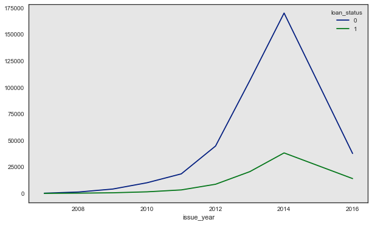

```python
LoanData['issue_year']=LoanData.issue_dt.dt.year
#LoanData['issue_month']=LoanData.issue_dt.dt.month
LoanData['issue_month']=LoanData.issue_dt.dt.strftime("%b")
#LoanData['Count']=1
# plot data
fig, ax = plt.subplots(figsize=(10,6))
# use unstack()
LoanData.groupby(['issue_year','loan_status']).count()['issue_month'].unstack().plot(ax=ax)
```

**Charge-off Rate by Year**:

The above chart helps us under the distribution of good vs bad loans but just to get a cleared idea of the trend, we should take a close look at the rate of bad loans over the years. It is important to note that we are only looking at one quarter of originations for 2016, so may not need to read too much into the trend as it doesn't include the rest of the year.

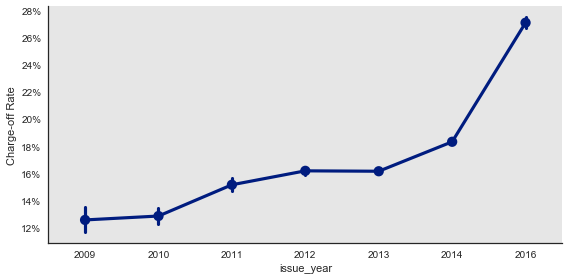

```python
from matplotlib.ticker import FuncFormatter
g = sns.factorplot(x="issue_year",y="loan_status",  data=LoanData[(LoanData.issue_year>2008) & (LoanData.issue_year<=2016)], kind="point",size=4, aspect=2);

g.ax.yaxis.set_major_formatter(FuncFormatter(lambda y, _: '{:.0%}'.format(y)))
g.set_ylabels("Charge-off Rate")
```

Reviewing the above chart shows a clear trend of rise in borrowers who are failing to repay their loan fully, making a need of the type of model we are proposing even more critical

**Numerical Variables**:

In the prior set of sanity checks, we took a look at the distribution by categorical variables. Here, we will start by reviewing the numerical variables. Specifically, we will review the correlations between numerical variables. The primary motivation to check correlations is to assess if we have features which move together (either in same or opposite direction). If such variables, exist, we need to be careful incorporating them in our analysis as they could lead to Multicollinearity giving rise to instability in the coefficients(parameter estimates) obtained from fitting a linear model.

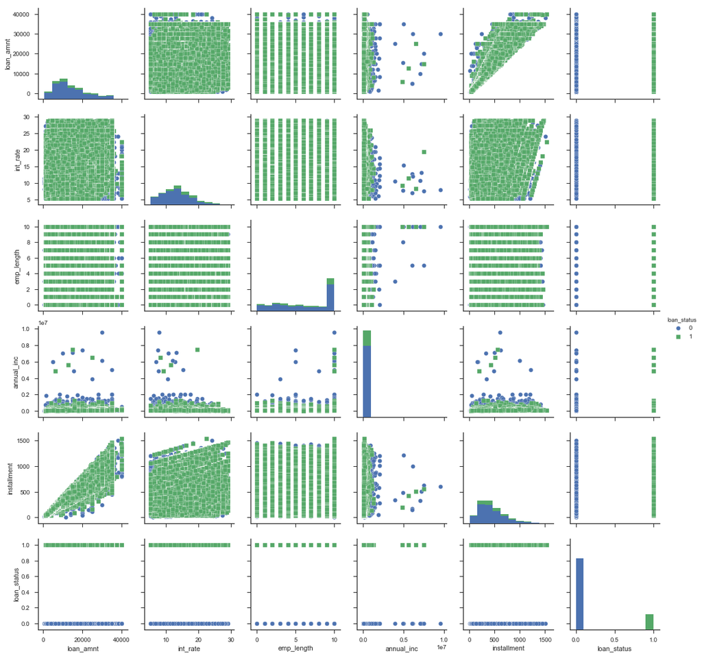

```python
import seaborn as sns; sns.set(style="ticks", color_codes=True)
loan_pairplot_df=LoanData[['loan_amnt','int_rate','emp_length',
                           'annual_inc','installment','loan_status']]
sns.pairplot(loan_pairplot_df,hue='loan_status', markers=["o", "s"])
```

```
Correlation among variables:
```

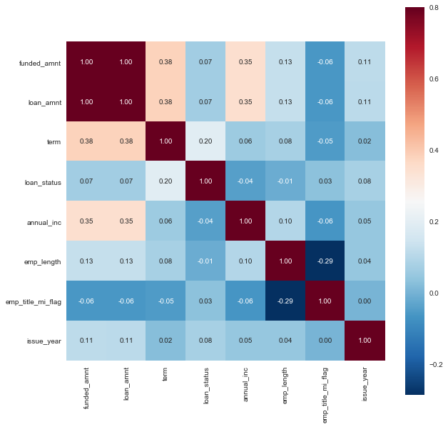

```python
# Check the correlation between selected attributes and displace using sns heatmap
remove_cols = ["installment",'total_pymnt','emp_length_mi_flag','int_rate']
select = [x for x in LoanData.columns if x not in remove_cols]
print("Correlation among variables:\n")
corr_mat = LoanData.loc[:, select].corr()
f, ax = plt.subplots(figsize=(10, 10))
sns.heatmap(corr_mat, vmax=.8, square=True, cmap="RdBu_r", annot=True, fmt='.2f', annot_kws={'size': 10});
```

*Funded and Loan Amounts* seem to be perfectly correlated, which implies that we can keep either one in our model. I will keep loan_amnt in our future analysis and the ratio of funded to loan amount as there could be some loans which are not fully funded (1.00 could simply be a rounding term displayed on the above correlogram.

We will next check if there is a differnece in such correlation if we were to look at the correlation by **loan_status** and other variables. This will help us de-averge any relationship between our independent variables and dependent variables.

Taking a closer look by **verification_status**, there does seem to be some difference but it's broadly coming from difference in the distribution of loan amounts in those categories.

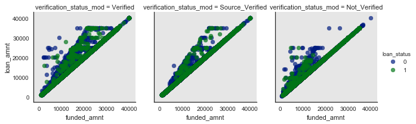

```python
g = sns.FacetGrid(LoanData, col="verification_status_mod", hue="loan_status",col_wrap=3)
g.map(plt.scatter, "funded_amnt", "loan_amnt", alpha=.7)
g.add_legend();
```

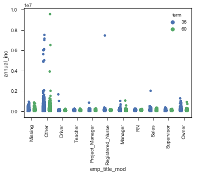

```python
plt.xticks(rotation=90)
sns.stripplot(data=LoanData[['term','annual_inc', 'emp_title_mod']], x='emp_title_mod', y='annual_inc', \
              jitter=True, hue='term', split=True)
```

Next, we will take a closer look at the categorical features available to us and here we will review both the distribution by each of the features along with the event rate (charge-off rate in this case).

**Distribution of Loans by Purpose and Home ownership**:

```python
LoanData.loc[LoanData.purpose<>'other',['purpose','home_ownership','loan_status']].purpose.value_counts()
```

```
debt_consolidation    280676
credit_card           106634
home_improvement       27805
major_purchase         10401
small_business          7083
car                     5680
medical                 4961
moving                  3208
vacation                2749
house                   2415
wedding                 2269
renewable_energy         375
educational              325
Name: purpose, dtype: int64
```

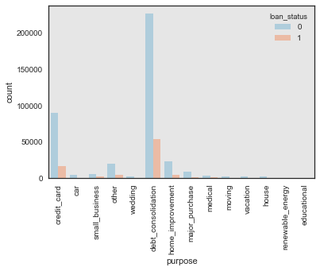

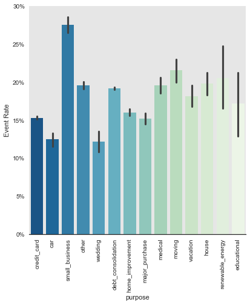

```python
reload(vs)
ax1,ax2 = vs.dist_by_cat(LoanData, 'purpose',"loan_status")
```

Looking at the chart above (bottom), one can easily observe that loans borrowed for the purpose _small_business_are way riskier than any other category. However, looking at the chart on the top, we can see it's only a small proportion of total accounts.

There could be factors like *seasonality* that can play a major role in financial data. For example, some borrowers could be credit hungry right before the holidays for shopping needs. Let's try to look at the data by **issue_month**.

Looking at the below charts, it appears that we issue more loans during Oct, but it's actually loans issued in March, Feb and Jan which tend to be riskier.

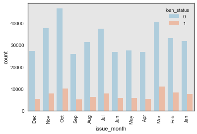

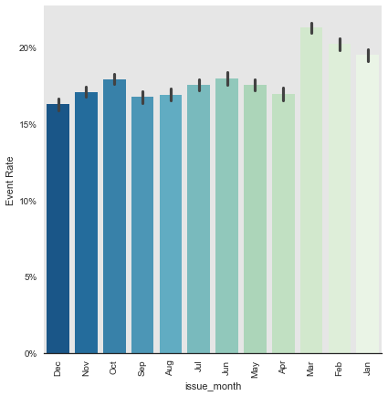

```python
reload(vs)
ax1,ax2 = vs.dist_by_cat(LoanData, 'issue_month',"loan_status")
```

Lastly, we will review the loans by **Home Ownership** information.

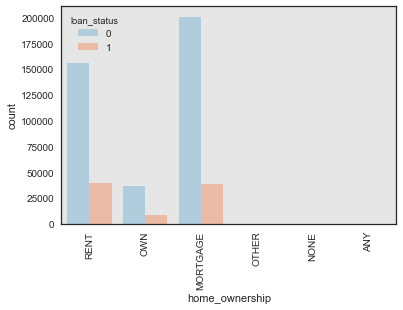

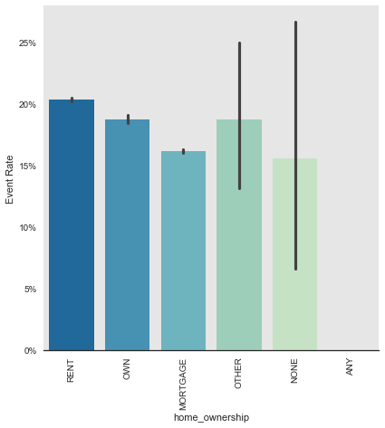

```python
reload(vs)
ax1,ax2 = vs.dist_by_cat(LoanData, 'home_ownership',"loan_status")
```

The above chart appear to convey that while most of our borrowers are home-owners, it is actually renters who tend to be riskier. All this information can be later verified when we develop our model.

**Interaction Effects**:

There could be effects which help us understand the relationship between multiple independent variables and our target. Such effect is called an *Interaction effect* and can yield interesting insights. To observe this, we will look at the risk rate by home ownership and purpose of the loan.

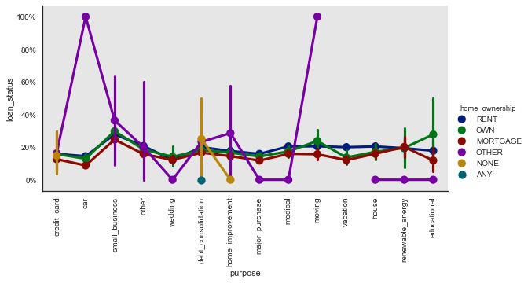

```python
g = sns.factorplot(x="purpose",y="loan_status", hue="home_ownership",  data=LoanData[(LoanData.issue_year>2008) & (LoanData.issue_year<2016)], kind="point",size=4, aspect=2);
#col=loan_status
from matplotlib.ticker import FuncFormatter

g.ax.yaxis.set_major_formatter(FuncFormatter(lambda y, _: '{:.0%}'.format(y)))
g.set_xticklabels(rotation=90)
```

As the above lines cross each other at several points, it is leading me to think that there could be some two-way interactions that we may need to keep in mind when building a linear model which doesn't pick up such interactions like other Tree-based methods.

**Term**

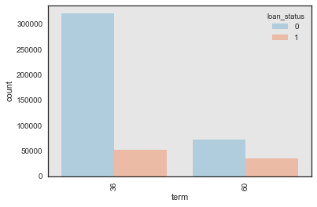

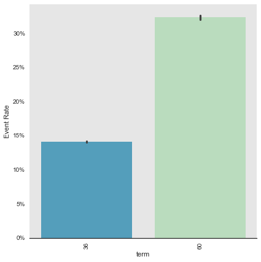

```python
LoanData.groupby(['term','issue_year']).count()['issue_dt'].sort_index()

#fig, ax = plt.subplots(figsize=(10,6))
# use unstack()
#LoanData.groupby(['issue_year','term']).count()['issue_dt'].unstack().plot(ax=ax)
ax1,ax2 = vs.dist_by_cat(LoanData, 'term',"loan_status")
```

Whenever I observe such diverging trends, I like to de-average them by various cateogries to see if this is coming from a particular section of loans or it's prevalent in all categories.

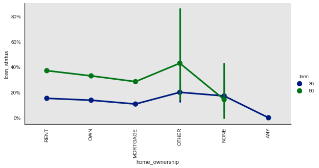

```python
g = sns.factorplot(x="home_ownership",y="loan_status", hue="term",  data=LoanData[(LoanData.issue_year>2008) & (LoanData.issue_year<2016)], kind="point",size=4, aspect=2);
#col=loan_status
from matplotlib.ticker import FuncFormatter

g.ax.yaxis.set_major_formatter(FuncFormatter(lambda y, _: '{:.0%}'.format(y)))
g.set_xticklabels(rotation=90)
```

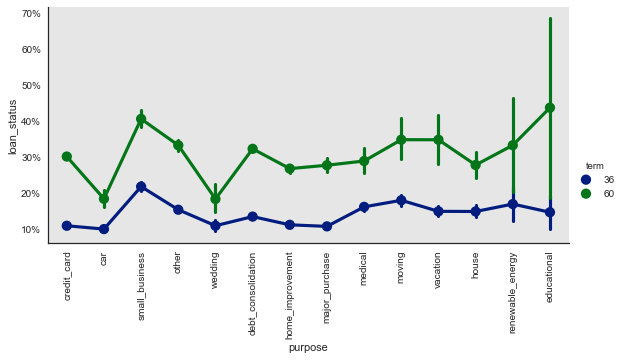

```python
g = sns.factorplot(x="purpose",y="loan_status", hue="term",  data=LoanData[(LoanData.issue_year>2008) & (LoanData.issue_year<2016)], kind="point",size=4, aspect=2);
#col=loan_status
from matplotlib.ticker import FuncFormatter

g.ax.yaxis.set_major_formatter(FuncFormatter(lambda y, _: '{:.0%}'.format(y)))
g.set_xticklabels(rotation=90)
```

**Categorical Variables**:

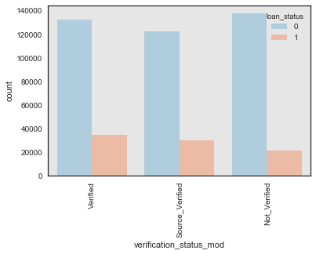

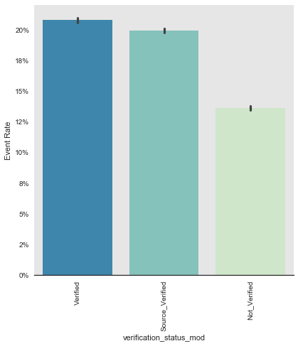

```python
#LoanData.purpose.value_counts().plot(kind='bar')
ax1,ax2 = vs.dist_by_cat(LoanData, 'verification_status_mod',"loan_status")
```

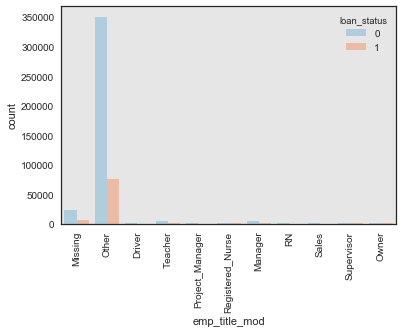

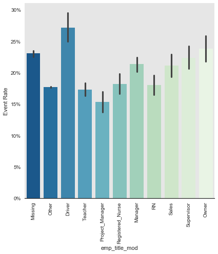

```python
reload(vs)
ax1,ax2 = vs.dist_by_cat(LoanData, 'emp_title_mod',"loan_status")
```

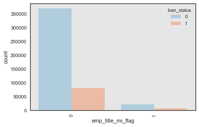

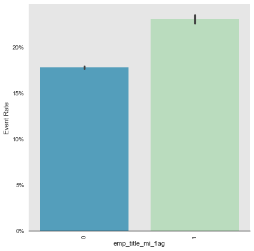

```python
reload(vs)
ax1,ax2 = vs.dist_by_cat(LoanData, 'emp_title_mi_flag',"loan_status")
```

**Multi-variate Distributions to get a better sense of data**:

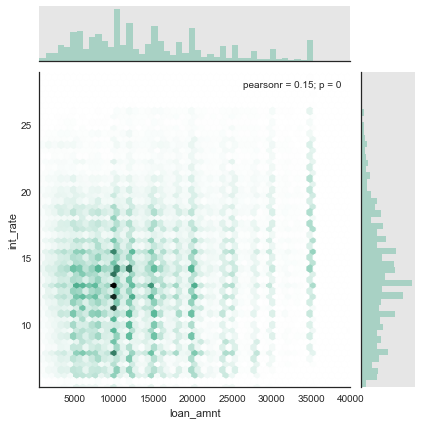

```python
g=sns.jointplot(x="loan_amnt", y="int_rate",data=LoanData
              , kind="hex",  color="#4CB391")
```

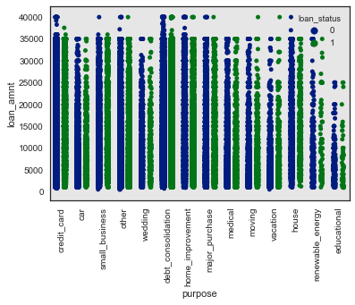

```python
plt.xticks(rotation=90)
sns.stripplot(data=LoanData[['loan_status','loan_amnt', 'purpose']], x='purpose', y='loan_amnt', \
              jitter=True, hue='loan_status', split=True)
```

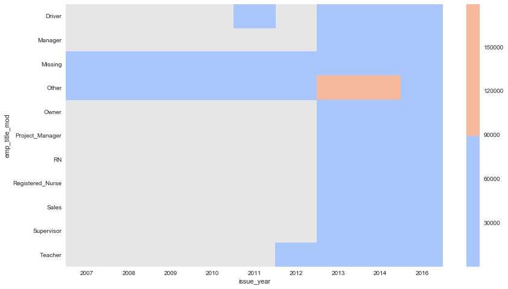

```python
loan_data_copy=LoanData.copy()
loan_data_copy['Count']=1
a4_dims = (14, 8)
fig, ax = plt.subplots(figsize=a4_dims)
ax.tick_params(labelsize=10)
subset_2_char=loan_data_copy.pivot_table('Count',index=['emp_title_mod'],columns=['issue_year'],aggfunc='sum')
g=sns.heatmap(subset_2_char, xticklabels=1,cmap=sns.color_palette("coolwarm", 2))#sns.dark_palette("muted purple", input="xkcd")
```

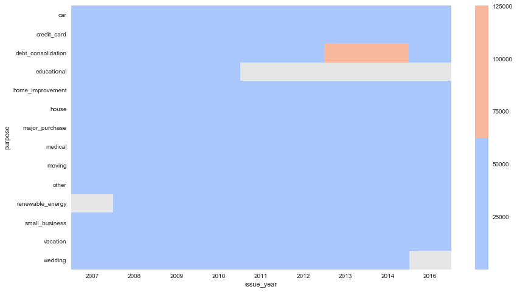

```python
loan_data_copy=LoanData.copy()
loan_data_copy['Count']=1
a4_dims = (14,8)
fig, ax = plt.subplots(figsize=a4_dims)
ax.tick_params(labelsize=10)
subset_2_char=loan_data_copy.pivot_table('Count',index=['purpose'],columns=['issue_year'],aggfunc='sum')
g=sns.heatmap(subset_2_char, xticklabels=1,cmap=sns.color_palette("coolwarm", 2))
```

### Algorithms and Techniques

In this section, you will need to discuss the algorithms and techniques you intend to use for solving the problem. You should justify the use of each one based on the characteristics of the problem and the problem domain. Questions to ask yourself when writing this section:

- *Are the algorithms you will use, including any default variables/parameters in the project clearly defined?*
- *Are the techniques to be used thoroughly discussed and justified?*
- *Is it made clear how the input data or datasets will be handled by the algorithms and techniques chosen?*

### Algorithms

* __Extension of the solution that can improve the solution__:*

__Logistic Regression__:

This is a supervised technique which is able to classify our targe using a linear boundary. It is popular approach for classification problems as it can generate insights by not only showing features that affect the performance but also by easy to interpret impact of these features by providing coeffecients. It takes into consideration the observerd data and identifiess the relationships between input feature and log-odds of event we are interested in predicting. It provides weights to each input feature, combines them together (and adds a bias) and using a sigmoid transformation, returns a probability (log-odds) associated with the event of interest. This provides us a nice way to understand the impact of changing any input feature on the desired outcome.*

_Benefits_:

- Simplistic Approach
- Fast to Train
- Probabilistic approach
- Returns p-values provding statistical significance of features

_Cons_:

- Cannot identify non-linear boundaries
- Requires variable treatment like interaction variables

__Random Forest__

It is a popular ensemble technique which is built upon the idea of collective intelligence of many decision trees built of subset of data and features. It is a simple idea of taking many decision trees and having them vote almost like having a committee of experts vote by looking at different aspects of a problem at any given time. A single Decision Tree has low bias and high variance, i.e., it may be difficult to take an individual decision tree and generalize it to new datasets. We overcome the high variance and inability of Decision Trees to predict on newer data by building not one but many trees. However, we don't build many trees on the same data, rather, we take sample of rows and features in each step of tree building and this helps the algorithm to generalize. Only those features that matter will repeatedly show up as important splitting criteria on many different trees.*

_Benefits_:

- Identifies non-linear boundaries
- Faster to train when compared to other ensemble techniquest
- Can be parallelized

_Cons_:

- Black-Box, lacks interpretability
- Easy to overfit
- Requires careful hyperparameter tuning (number of trees, tree depth etc.)

__Gradient Boosting__

This is another ensemble technique which has shown promise in recent years. It is built upon the idea of taking a weak learner and then try to improve upon the predictions by assigning higher weight to instances which were previously incorrectly classified. Here, we are sequentially trying to improve the results and instead of voting, we weigh the weak learners to come up with the final prediction. This can be slow at times as the weak learners (often trees) are grown sequentially and can't be parallelized like Random Forest. The reason the approach is called Gradient Boosting is because the algorithm uses Gradient Descent to optimize a given loss function when it sequentially builds trees.*

__Benefits__:

- Identifies non-linear boundaries
- Highly accurate and can have best performance among ensemble techniques

__Cons__:

- Slow to train
- Sensitive to outliers
- Black-Box, lacks interpretability
- As trees are built sequentially on residuals, it is not possible to parallelize (althought xgboost has recently tried to parallelize this)
- Requires careful hyperparameter tuning, else can lead to overfitting (learning rate, number of estimators etc.)

### Benchmark

In this section, you will need to provide a clearly defined benchmark result or threshold for comparing across performances obtained by your solution. The reasoning behind the benchmark (in the case where it is not an established result) should be discussed. Questions to ask yourself when writing this section:

- *Has some result or value been provided that acts as a benchmark for measuring performance?*
- *Is it clear how this result or value was obtained (whether by data or by hypothesis)?*

Our benchmark is not only going to be a model output but also a dollar threshold. As we plan to leverage 2016 (Q1) loan originations as our validation datasets, we will check how much money Lending Club made/lost on those bookings.

The reason this serves as a good benchmark is because it already takes into conisderataion the credit policy and the funding criteria applied by Lending Club (i.e. individual investors).

Our benchmark model will be a naive classifier which uses the most predictive information available to us, i.e. Loan Grades and interest rates. In the scenario where we don't really know what Lending Club's model looks like, I thought it may be a good idea to use an output of their complex model to assess if it helps classify risk.

At the same time, we have the privilege of comparing it to the actual outcome of someone either paying the loan back or not.

Let's verify this holds true.

**Interest Rate**:

Another important variable that can help assess whether an account is risky is interest rate. Often the interest rates are closely associated with the risk profile of a borrower, i.e. higher risk customers tend to get loans approved at higher interest rates due to perceived notion of credit hungriness.

The below chart helps confirm that theory as most of the defaulted loans had higher interest rates than those who paid the loans fully.

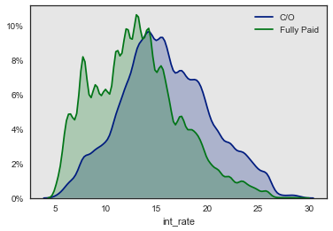

```python
sns.kdeplot(LoanData.int_rate[LoanData.loan_status==1], label='C/O', shade=True)
sns.kdeplot(LoanData.int_rate[LoanData.loan_status==0], label='Fully Paid', shade=True).yaxis.set_major_formatter(FuncFormatter(lambda y, _: '{:.0%}'.format(y)))

plt.xlabel('int_rate');
```

At the same time, we should also confirm the risk sloping by interst rates. The below chart confirms our assumption thatt the riskier grades had higher interest rates.

###### Distribution by Loan Grade and Interest Rates

If the ranking holds true, we should also observe separtion between distribution by interest rates for good and defaulted loans. Here we have verified the same.

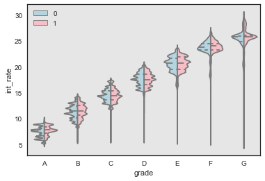

```python
p2 = sns.violinplot(data=LoanData[['loan_status', 'int_rate', 'grade']], hue='loan_status',
                    x='grade', \
               order=['A', 'B', 'C', 'D', 'E', 'F', 'G'], y='int_rate',
                    split=True, inner='quartile', palette=["lightblue", "lightpink"],cut=4)

plt.legend(loc='upper left')
plt.xticks(rotation=0)


#https://jakevdp.github.io/PythonDataScienceHandbook/04.14-visualization-with-seaborn.html
```